# Logistic Regression and Further Study

2025-11-03

The full outline for this individual section is on the folder “Billy” and under “Logistic Regression.md” on GitHub. Note that we have attempted to make the data as independent as possible, yet there will still be data leakage from the companies in the training set being dependent (if they are the same company) hence to proceed it is important to be wary of this.

```r
pkgs <- c("pROC", "car", "glmnet", "logistf")

for(p in pkgs){
    if (!require(p,character.only=TRUE)) install.packages(p)
}
file_path <- c("../Data/Val_traindata/df_train_log_scaled_val.csv", "../Data/Val_traindata/df_test_log_scaled_val.csv")
train_val <- read.csv(file_path[1])
test_val <- read.csv(file_path[2])
```

We will now convert the status year columns into numerical targets, a form of binary encoding, with 0 for “alive” and 1 for “failed”.

```r
cols <- c("status_label_1yr", "status_label_2yr", "status_label_3yr")

for (col in cols) {
  train_val[[col]] <- ifelse(train_val[[col]] == "failed", 1, 0)
  test_val[[col]]  <- ifelse(test_val[[col]] == "failed", 1, 0)
}
```

As explained in the group part of the report, we have introduced lag variables so it is important that we categorise them for easier use in the future.

```r
features <- paste0("X", 1:18)
features <- features[features !=  "X16"]
lag_1yr_feats <- paste0(features, "_1yr")
lag_2yr_feats <- paste0(features, "_2yr")
lag_3yr_feats <- paste0(features, "_3yr")

print(features)
```

```
##  [1] "X1"  "X2"  "X3"  "X4"  "X5"  "X6"  "X7"  "X8"  "X9"  "X10" "X11" "X12"
## [13] "X13" "X14" "X15" "X17" "X18"
```

We will now plot our simple logistic regression model, only considering base features and with respect to status_label_1yr.

```r
formula_base <- as.formula(paste("status_label_1yr ~", paste(features, collapse = " + ")))
model_base <- glm(formula_base, data = train_val, family = binomial())
summary(model_base)
```

```
##
## Call:
## glm(formula = formula_base, family = binomial(), data = train_val)
##
## Deviance Residuals:
##     Min       1Q   Median       3Q      Max
## -1.2834  -0.1305  -0.0764  -0.0465   4.1965
##
## Coefficients:
##             Estimate Std. Error z value Pr(>|z|)
## (Intercept) -5.70093    0.14258 -39.984  < 2e-16 ***
## X1          -0.94748    0.35833  -2.644 0.008190 **
## X2           0.12781    0.45758   0.279 0.779999
## X3          -0.16613    0.25999  -0.639 0.522831
## X4          -0.08188    0.17383  -0.471 0.637607
## X5           0.13986    0.15633   0.895 0.370972
## X6          -0.41276    0.13620  -3.031 0.002441 **
## X7          -0.72373    0.18073  -4.004 6.22e-05 ***
## X8          -1.20346    0.14984  -8.032 9.63e-16 ***
## X9          -0.67145    0.52435  -1.281 0.200353
## X10         -0.20997    0.40373  -0.520 0.603012
## X11         -0.07048    0.15657  -0.450 0.652602
## X12         -0.23484    0.15319  -1.533 0.125277
## X13          0.22253    0.18064   1.232 0.218001
## X14          1.29461    0.33787   3.832 0.000127 ***
## X15         -0.29706    0.12780  -2.324 0.020103 *
## X17          0.78386    0.43991   1.782 0.074771 .
## X18          1.35381    0.60622   2.233 0.025535 *
## ---
## Signif. codes:  0 '***' 0.001 '**' 0.01 '*' 0.05 '.' 0.1 ' ' 1
##
## (Dispersion parameter for binomial family taken to be 1)
##
##     Null deviance: 2220.8  on 19062  degrees of freedom
## Residual deviance: 1714.3  on 19045  degrees of freedom
## AIC: 1750.3
##
## Number of Fisher Scoring iterations: 9
```

Recall that from the EDA section that there is high correlation between variables. We will explore this more after our initial testing.

```r
formulas <- list(
  base = as.formula(paste("status_label_1yr ~", paste(features, collapse = " + "))),
  base_lag1 = as.formula(paste("status_label_1yr ~", paste(c(features, lag_1yr_feats), collapse = " + "))),
  base_lag1_2 = as.formula(paste("status_label_1yr ~", paste(c(features, lag_1yr_feats, lag_2yr_feats), collapse = " + "))),
  all = as.formula(paste("status_label_1yr ~", paste(c(features, lag_1yr_feats, lag_2yr_feats, lag_3yr_feats), collapse = " + ")))
)

models <- list()
for (i in names(formulas)) {
  f <- formulas[[i]]
  models[[i]] <- glm(f, data = train_val, family = binomial())
}

for (i in names(models)) {
  cat("\nModel:", i, "\n")
  cat("AIC:", AIC(models[[i]]), "\n")
}
```

```
##
## Model: base
## AIC: 1750.251
##
## Model: base_lag1
## AIC: 1732.086
##
## Model: base_lag1_2
## AIC: 1746.126
##
## Model: all
## AIC: 1746.773
```

```r
glm_probs <- list()
for (i in names(models)) {
  mod <- models[[i]]
  glm_probs[[i]] <- predict(mod, newdata = test_val, type = "response")
}

roc_list <- list()
auc_values <- numeric()

for (i in names(glm_probs)) {
  roc_list[[i]] <- roc(test_val$status_label_1yr, glm_probs[[i]])
  auc_values[i] <- auc(roc_list[[i]])
}
# view AUC results
print(round(auc_values, 3))
```

```
##        base   base_lag1 base_lag1_2         all
##       0.901       0.866       0.869       0.805
```

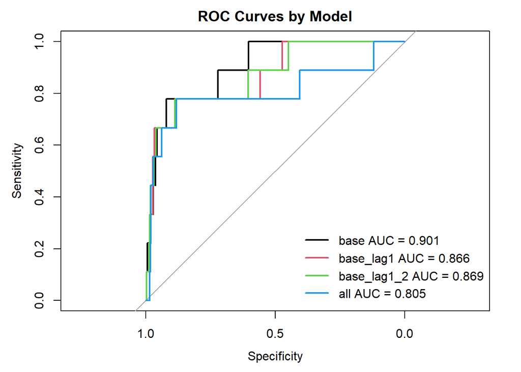

```r
plot(roc_list[[1]], col = 1, lwd = 2, main = "ROC Curves by Model")
for (j in 2:length(roc_list)) {
  lines(roc_list[[j]], col = j, lwd = 2)
}

legend("bottomright",
       legend = paste(names(roc_list), "AUC =", round(auc_values, 3)),
       col = 1:length(roc_list), lwd = 2, bty = "n")
```

```r
auc_df <- data.frame(
  Model = c("Base", "Base + Lag1", "Base + Lag1 + Lag 2", "Base + All Lags"),
  AUC = c(auc_values["base"], auc_values["base_lag1"], auc_values["base_lag1_2"], auc_values["all"])
)

print(auc_df)
```

```
##                           Model       AUC
## base                       Base 0.9008328
## base_lag1           Base + Lag1 0.8657681
## base_lag1_2 Base + Lag1 + Lag 2 0.8689459
## all             Base + All Lags 0.8050625
```

```r
best_index <- which.max(auc_df$AUC)
best_model_name <- auc_df$Model[best_index]
print(best_model_name)
```

```
## [1] "Base"
```

```r
thresh <- coords(roc_list[[1]], "best", ret = "threshold")
glm.pred <- ifelse(glm_probs[[1]] > thresh$threshold, 1, 0)
actual <- test_val$status_label_1yr

cm <- table(Predicted = glm.pred, Actual = actual)
cm
```

```
##          Actual
## Predicted   0   1
##         0 933   2
##         1  81   7
```

```r
TP <- cm[2, 2]
TN <- cm[1, 1]
FP <- cm[2, 1]
FN <- cm[1, 2]

accuracy  <- (TP + TN) / sum(cm)
precision <- TP / (TP + FP)
recall    <- TP / (TP + FN)
f1_score  <- 2 * precision * recall / (precision + recall)

cat("Accuracy :", round(accuracy, 3), "\n")
```

```
## Accuracy : 0.919
```

```r
cat("Precision:", round(precision, 3), "\n")
```

```
## Precision: 0.08
```

```r
cat("Recall   :", round(recall, 3), "\n")
```

```
## Recall   : 0.778
```

```r
cat("F1 Score :", round(f1_score, 3), "\n")
```

```
## F1 Score : 0.144
```

We see that the the base model has the highest AUC. We then calculate the confusion matrix and see that we have low precision but high recall. This is because our model is incorrectly flagging many companies as bankrupt when they do in fact not go bankrupt. However, the high recall score does mean that the model is correctly flagging companies that are bankrupt as correct, which is the more important application. Thus, with a score of 0.9 our base model can correctly distinguish between bankrupt and non bankrupt companies very well.

It is important to note that even with a high AUC score it does not necessarily mean our model is necessarily excellent. This is because of the low precision score. Therefore, if one were to improve this whilst maintaining a high AUC, then it would lend credence into the belief that the model is truthfully “excellent”.

We now extend our findings by removing all highly correlated variables. We choose said variables by the correlation analysis done in the EDA section of the report.

```r
new_features <- features[-c(2,4,9,10)]
lag_1yr_newfeats <- paste0(new_features, "_1yr")
lag_2yr_newfeats <- paste0(new_features, "_2yr")
lag_3yr_newfeats <- paste0(new_features, "_3yr")

print(new_features)
```

```
##  [1] "X1"  "X3"  "X5"  "X6"  "X7"  "X8"  "X11" "X12" "X13" "X14" "X15" "X17"
## [13] "X18"
```

```r
formulas_new <- list(
  base_new = as.formula(paste("status_label_1yr ~", paste(new_features, collapse = " + "))),
  base_lag1_new = as.formula(paste("status_label_1yr ~", paste(c(new_features, lag_1yr_newfeats), collapse = " + "))),
  base_lag1_2_new = as.formula(paste("status_label_1yr ~", paste(c(new_features, lag_1yr_newfeats, lag_2yr_newfeats), collapse = " + "))),
  all_new = as.formula(paste("status_label_1yr ~", paste(c(new_features, lag_1yr_newfeats, lag_2yr_newfeats, lag_3yr_newfeats), collapse = " + ")))
)

models_new <- list()
for (i in names(formulas_new)) {
  f <- formulas_new[[i]]
  models_new[[i]] <- glm(f, data = train_val, family = binomial())
}

for (i in names(models_new)) {
  cat("\nModel:", i, "\n")
  cat("AIC:", AIC(models_new[[i]]), "\n")
}
```

```
##
## Model: base_new
## AIC: 1744.868
##
## Model: base_lag1_new
## AIC: 1725.479
##
## Model: base_lag1_2_new
## AIC: 1736.983
##
## Model: all_new
## AIC: 1728.993
```

```r
glm_probs_new <- list()
for (i in names(models_new)) {
  mod <- models_new[[i]]
  glm_probs_new[[i]] <- predict(mod, newdata = test_val, type = "response")
}

roc_list_new <- list()
auc_values_new <- numeric()

# loop through all predicted probability vectors
for (i in names(glm_probs_new)) {
  roc_list_new[[i]] <- roc(test_val$status_label_1yr, glm_probs_new[[i]])
  auc_values_new[i] <- auc(roc_list_new[[i]])
}
# view AUC results
print(round(auc_values_new, 3))
```

```
##        base_new   base_lag1_new base_lag1_2_new         all_new
##           0.904           0.874           0.875           0.808
```

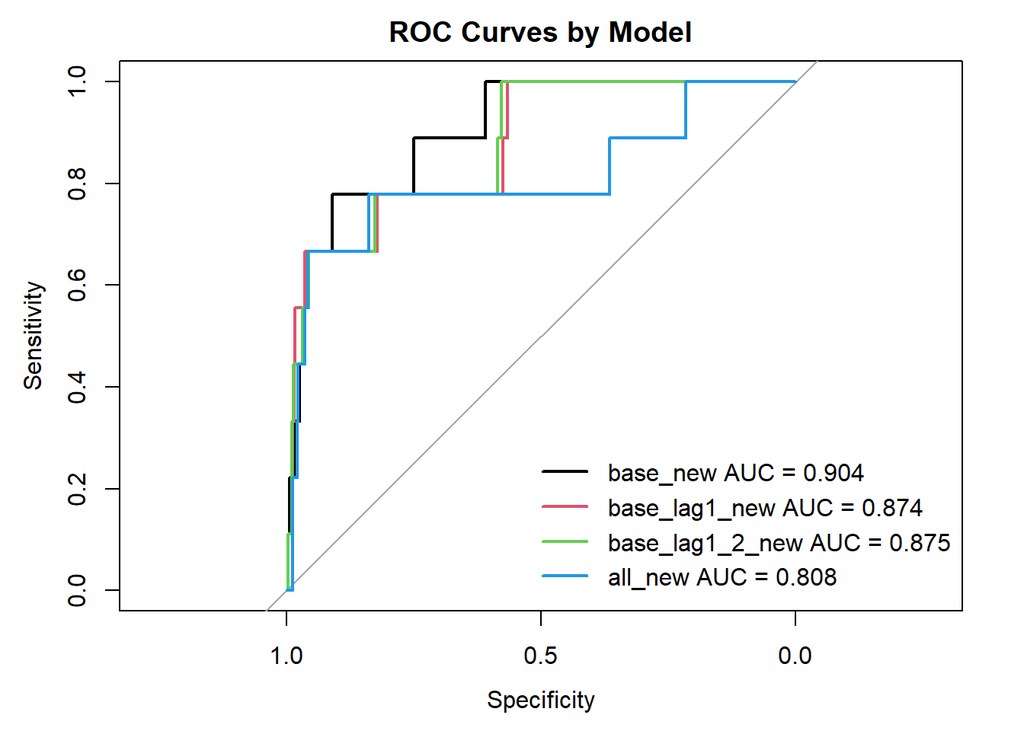

```r
# list roc plot
plot(roc_list_new[[1]], col = 1, lwd = 2, main = "ROC Curves by Model")
for (j in 2:length(roc_list_new)) {
  lines(roc_list_new[[j]], col = j, lwd = 2)
}

legend("bottomright",
       legend = paste(names(roc_list_new), "AUC =", round(auc_values_new, 3)),
       col = 1:length(roc_list_new), lwd = 2, bty = "n")
```

```r
auc_df_new <- data.frame(
  Model = c("Base", "Base + Lag1", "Base + Lag1 + Lag2", "Base + All Lags"),
  AUC = c(auc_values_new["base_new"], auc_values_new["base_lag1_new"], auc_values_new["base_lag1_2_new"], auc_values_new["all_new"])
)

print(auc_df_new)
```

```
##                              Model       AUC
## base_new                      Base 0.9041201
## base_lag1_new          Base + Lag1 0.8739864
## base_lag1_2_new Base + Lag1 + Lag2 0.8749726
## all_new            Base + All Lags 0.8079115
```

```r
best_index_new <- which.max(auc_df_new$AUC)
best_model_name_new <- auc_df_new$Model[best_index_new]
print(best_model_name_new)
```

```
## [1] "Base"
```

```r
thresh_new <- coords(roc_list_new[[1]], "best", ret = "threshold")
glm.pred_new <- ifelse(glm_probs_new[[1]] > thresh_new$threshold, 1, 0)
actual_new <- test_val$status_label_1yr

cm <- table(Predicted = glm.pred_new, Actual = actual_new)
cm
```

```
##          Actual
## Predicted   0   1
##         0 922   2
##         1  92   7
```

```r
TP <- cm[2, 2]
TN <- cm[1, 1]
FP <- cm[2, 1]
FN <- cm[1, 2]

accuracy  <- (TP + TN) / sum(cm)
precision <- TP / (TP + FP)
recall    <- TP / (TP + FN)
f1_score  <- 2 * precision * recall / (precision + recall)

cat("Accuracy :", round(accuracy, 3), "\n")
```

```
## Accuracy : 0.908
```

```r
cat("Precision:", round(precision, 3), "\n")
```

```
## Precision: 0.071
```

```r
cat("Recall   :", round(recall, 3), "\n")
```

```
## Recall   : 0.778
```

```r
cat("F1 Score :", round(f1_score, 3), "\n")
```

```
## F1 Score : 0.13
```

For further study, I attempted to weight variables to counter act the imbalance class size in the dataset using the method outlined in King (2001) [1] to determine our weightings. However, later discovered this method was not truly applicable given the circumstances. Attempt to use Firth logit (1993) [2], LASSO, Elastic Net and Ridge [3].

```r
models_firth <- list()
for (i in names(formulas)) {
  f <- formulas[[i]]
  models_firth[[i]] <- logistf(f, data = train_val)
}

glm_probs_firth <- list()
for (i in names(models_firth)) {
  mod <- models_firth[[i]]
  glm_probs_firth[[i]] <- predict(mod, newdata = test_val, type = "response")
}

roc_list_firth <- list()
auc_values_firth <- numeric()

for (i in names(glm_probs_firth)) {
  roc_list_firth[[i]] <- roc(test_val$status_label_1yr, glm_probs_firth[[i]])
  auc_values_firth[i] <- auc(roc_list_firth[[i]])
}
# view AUC results
print(round(auc_values_firth, 3))
```

```
##        base   base_lag1 base_lag1_2         all
##       0.902       0.870       0.877       0.812
```

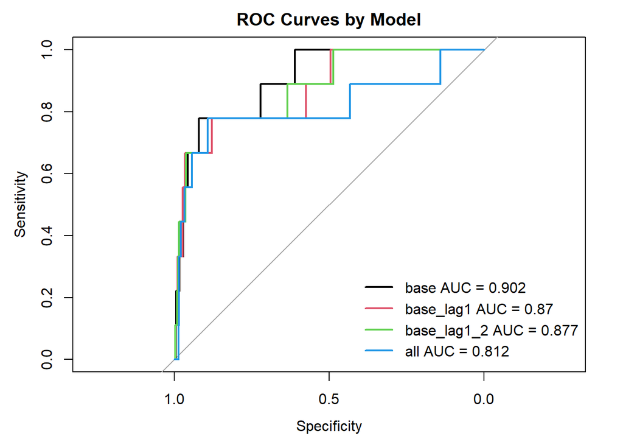

```r
plot(roc_list_firth[[1]], col = 1, lwd = 2, main = "ROC Curves by Model")
for (j in 2:length(roc_list_firth)) {
  lines(roc_list_firth[[j]], col = j, lwd = 2)
}

legend("bottomright",
       legend = paste(names(roc_list_firth), "AUC =", round(auc_values_firth, 3)),
       col = 1:length(roc_list_firth), lwd = 2, bty = "n")
```

```r
auc_df_firth <- data.frame(
  Model = c("Base", "Base + Lag1", "Base + Lag1 + Lag 2", "Base + All Lags"),
  AUC = c(auc_values_firth["base"], auc_values_firth["base_lag1"], auc_values_firth["base_lag1_2"], auc_values_firth["all"])
)

print(auc_df_firth)
```

```
##                           Model       AUC
## base                       Base 0.9017094
## base_lag1           Base + Lag1 0.8703704
## base_lag1_2 Base + Lag1 + Lag 2 0.8773833
## all             Base + All Lags 0.8122945
```

```r
best_index_firth <- which.max(auc_df_firth$AUC)
best_model_name_firth <- auc_df_firth$Model[best_index_firth]
print(best_model_name_firth)
```

```
## [1] "Base"
```

Slightly better results regarding AUC when using Firth. Again, further study could delve into the mathematical reasoning behind such a slight increase.

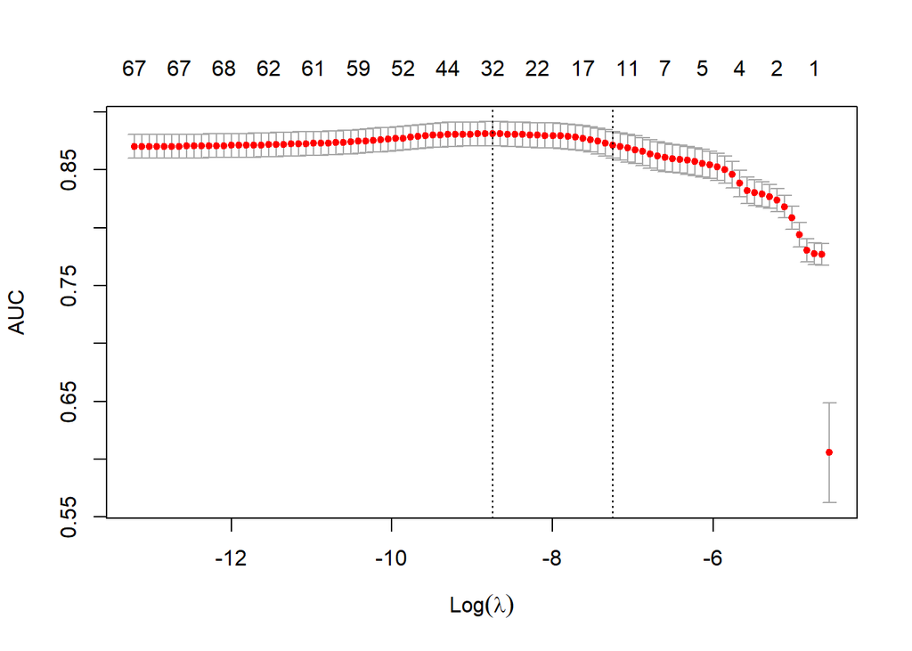

```r
y_train <- as.integer(train_val$status_label_1yr == "failed")
x_train <- model.matrix(~ . - X.1 - X - status_label_1yr - status_label_2yr - status_label_3yr - company_name - year, data = train_val)
set.seed(1)
cvfit <- cv.glmnet(x_train,  train_val$status_label_1yr, family = "binomial", alpha = 1, type.measure = "auc")
plot(cvfit)
```

```r
cvfit$lambda.min
```

```
## [1] 0.0001601329
```

```r
cvfit$lambda.1se
```

```
## [1] 0.0007094881
```

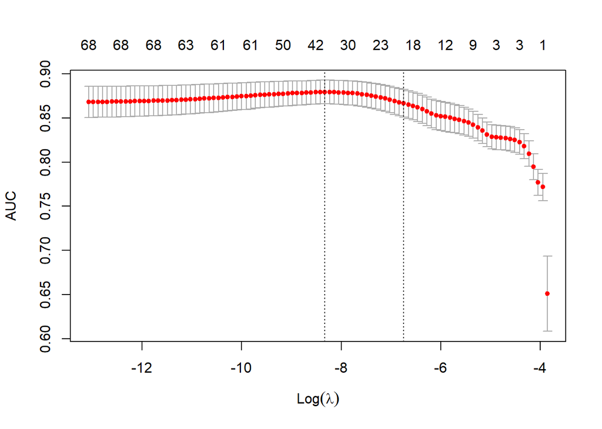

```r
cvfit_en <- cv.glmnet(x_train,  train_val$status_label_1yr, family = "binomial", alpha = 0.5, type.measure = "auc")
plot(cvfit_en)
```

```r
cvfit_en$lambda.min
```

```
## [1] 0.0002422693
```

```r
cvfit_en$lambda.1se
```

```
## [1] 0.001178059
```

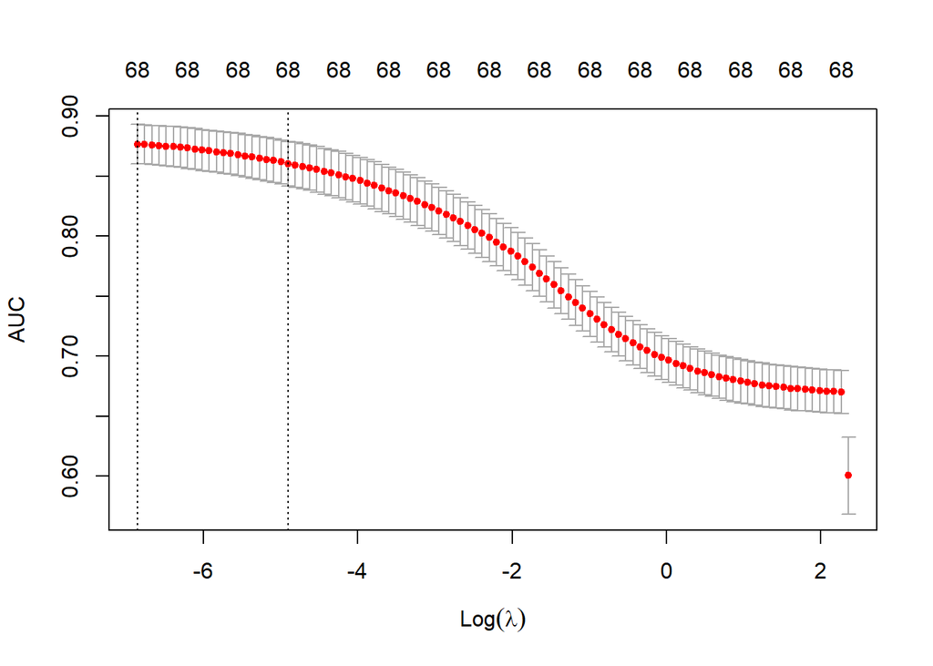

```r
cvfit_ridge <- cv.glmnet(x_train,  train_val$status_label_1yr, family = "binomial", alpha = 0, type.measure = "auc")
plot(cvfit_ridge)
```

```r
cvfit_ridge$lambda.min
```

```
## [1] 0.001053567
```

```r
cvfit_ridge$lambda.1se
```

```
## [1] 0.007432709
```

LASSO, Elastic Net and Ridge AUC is slightly below previous tests, although all remain high. Future study could inspect these penalisation methods more in depth.

Attempted to use “geenet” to account for the temporal aspects of the model, but was not able to apply it correctly. For future, attempt to implement this or similar techniques to tackle the autoregressive correlation structure between companies.

```r
file_path1 <- c("../Data/Final_traindata/df_train_log_scaled_full.csv", "../Data/Final_traindata/df_test_log_scaled.csv")
final_train <- read.csv(file_path1[1])
final_test <- read.csv(file_path1[2])

for (col in cols) {
  final_train[[col]] <- ifelse(final_train[[col]] == "failed", 1, 0)
  final_test[[col]]  <- ifelse(final_test[[col]] == "failed", 1, 0)
}

model_base_final <- glm(formulas[[1]], data = final_train, family = binomial())

glm_probs_basefinal = predict(model_base_final, newdata = final_test, type ="response")
roc_objbfinal <- roc(final_test$status_label_1yr, glm_probs_basefinal)
final_thresh <- coords(roc_objbfinal, "best", ret = "threshold")

glm.pred <- ifelse(glm_probs_basefinal > final_thresh$threshold, 1, 0)
actual <- final_test$status_label_1yr

cm <- table(Predicted = glm.pred, Actual = actual)
cm
```

```
##          Actual
## Predicted    0    1
##         0 2085    5
##         1  307   24
```

```r
TP <- cm[2, 2]
TN <- cm[1, 1]
FP <- cm[2, 1]
FN <- cm[1, 2]

accuracy  <- (TP + TN) / sum(cm)
precision <- TP / (TP + FP)
recall    <- TP / (TP + FN)
f1_score  <- 2 * precision * recall / (precision + recall)

cat("Accuracy:", round(accuracy, 3), "\n")
```

```
## Accuracy: 0.871
```

```r
cat("Precision:", round(precision, 3), "\n")
```

```
## Precision: 0.073
```

```r
cat("Recall:", round(recall, 3), "\n")
```

```
## Recall: 0.828
```

```r
cat("F1 Score:", round(f1_score, 3), "\n")
```

```
## F1 Score: 0.133
```

```r
cat("Base Model AUC:", roc_objbfinal$auc, "\n")
```

```
## Base Model AUC: 0.9128561
```

[figure not shown]

```r
plot(roc_list[[1]], col = 1, lwd = 2, main = "Final ROC Curves by Model")
legend("bottomright", legend = paste(("Base"), "AUC =", round(roc_objbfinal$auc, 3)), col = 1, lwd = 2, bty = "n")
```

```r
model_base_final_new <- glm(formulas_new[[1]], data = final_train, family = binomial())

glm_probs_basefinal_new = predict(model_base_final_new, newdata = final_test, type ="response")
roc_objbfinal_new <- roc(final_test$status_label_1yr, glm_probs_basefinal_new)
final_thresh_new <- coords(roc_objbfinal_new, "best", ret = "threshold")

glm.pred_new <- ifelse(glm_probs_basefinal_new > final_thresh_new$threshold, 1, 0)
actual_new <- final_test$status_label_1yr

cm <- table(Predicted = glm.pred_new, Actual = actual_new)
cm
```

```
##          Actual
## Predicted    0    1
##         0 1977    4
##         1  415   25
```

```r
TP <- cm[2, 2]
TN <- cm[1, 1]
FP <- cm[2, 1]
FN <- cm[1, 2]

accuracy  <- (TP + TN) / sum(cm)
precision <- TP / (TP + FP)
recall    <- TP / (TP + FN)
f1_score  <- 2 * precision * recall / (precision + recall)

cat("Accuracy:", round(accuracy, 3), "\n")
```

```
## Accuracy: 0.827
```

```r
cat("Precision:", round(precision, 3), "\n")
```

```
## Precision: 0.057
```

```r
cat("Recall:", round(recall, 3), "\n")
```

```
## Recall: 0.862
```

```r
cat("F1 Score:", round(f1_score, 3), "\n")
```

```
## F1 Score: 0.107
```

```r
cat("Base Model AUC:", roc_objbfinal_new$auc, "\n")
```

```
## Base Model AUC: 0.9169358
```

[figure not shown]

```r
plot(roc_list_new[[1]], col = 1, lwd = 2, main = "Final ROC Curves by Model")
legend("bottomright", legend = paste(("Base"), "AUC =", round(roc_objbfinal_new$auc, 3)), col = 1, lwd = 2, bty = "n")
```

A more in depth conclusion is provided in the aforementioned markdown file on and the report section. We see that the best model in regards to AUC is the base model (no lag features) whilst removing highly correlated variables. To improve this result, one could explore penalisation methods in more depth and/or explore other performance metrics such as PR-AUC which may show that a separate model is “better”.

References: [1] https://gking.harvard.edu/sites/g/files/omnuum7116/files/gking/file [2] https://academic.oup.com/biomet/article/80/1/27/228364?login=true [3] https://glmnet.stanford.edu/articles/glmnet.html#logistic-regression-family-binomial